# multispectral_drone_svh — results report

Gemmell et al., *Applying the spectral variability hypothesis to arid shrublands

2026-05-25

# Overview

This report is the canonical results document for the analysis pipeline driven by `_targets.R`. It loads every figure and table from cached targets via `tar_read()`, so it will rebuild only when an upstream target changes — re-running it requires only a working `_targets/` cache (i.e. after `targets::tar_make()` has succeeded at least once).

# Workflow

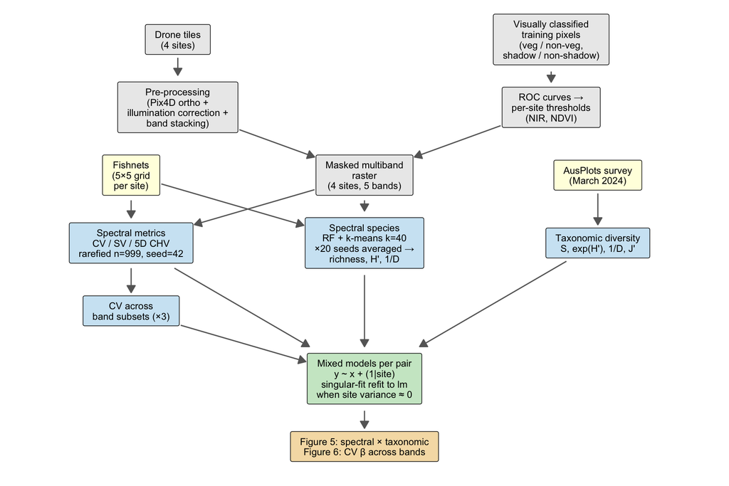

Figure 1. Analysis workflow from preprocessing through to manuscript figures. The preprocessing block (above the dashed line in the README version of this diagram) is upstream of the targets pipeline and produces the Zenodo-archived rasters; see `preprocessing/` for those scripts.

# Figure 5 — spectral vs taxonomic diversity

Per-subplot scatter plots of taxonomic diversity (species richness *S*, exp(*H*’), 1/*D*, Pielou *J*’) against each of the three continuous spectral metrics (coefficient of variation *CV*, spectral variance *SV*, log convex-hull volume *log CHV*), with significant-relationship overlay lines drawn from the cached `glmmTMB` / `lm` fits.

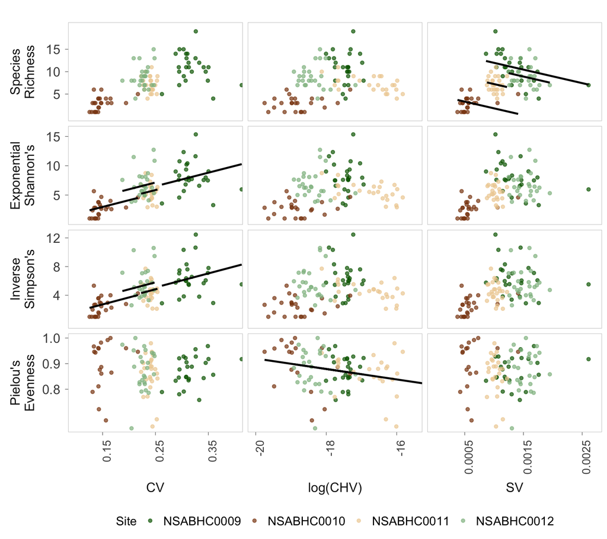

Figure 5. Spectral vs taxonomic diversity across the four arid-NSW sites.

# Figure 6 — CV across band combinations

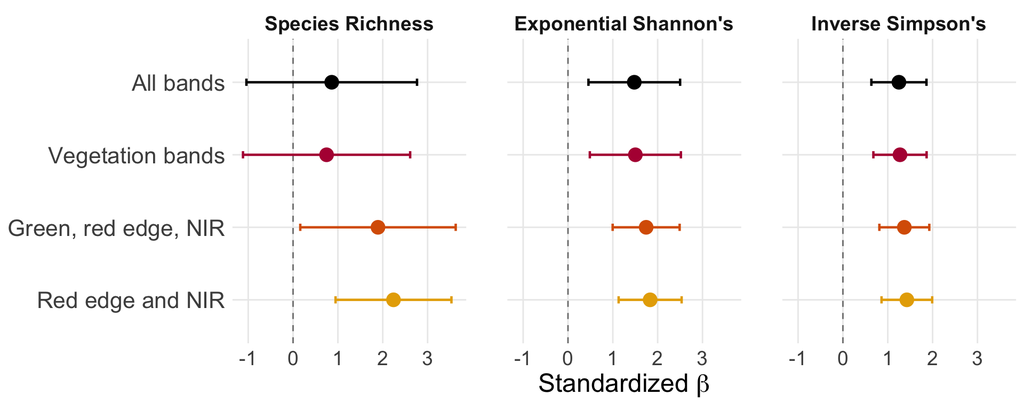

Figure 6. CV beta coefficients across band combinations.

# Model summary tables

## Continuous spectral metrics × taxonomic diversity

Mixed models (`glmmTMB`, site as random intercept) for each of the 12 taxonomic × spectral pairs. The three `pielou_evenness` rows are refit as fixed-effect linear models because the mixed specification is singular (site σ ≈ 0); they’re tagged `model_kind = "fixed"`.

| taxonomic | spectral | kind | β | 95% CI lower | 95% CI upper | p | R² marginal | R² conditional |
| --- | --- | --- | --- | --- | --- | --- | --- | --- |
| species_richness | CV | mixed | 0.862 | -1.040 | 2.765 | 3.74e-01 | 0.065 | 0.470 |
| species_richness | SV | mixed | -1.279 | -2.138 | -0.421 | 3.49e-03 | 0.073 | 0.763 |
| species_richness | log.CHV | mixed | -0.423 | -1.312 | 0.465 | 3.50e-01 | 0.012 | 0.626 |
| exp_shannon | CV | mixed | 1.479 | 0.457 | 2.500 | 4.57e-03 | 0.307 | 0.395 |
| exp_shannon | SV | mixed | -0.586 | -1.343 | 0.172 | 1.30e-01 | 0.033 | 0.616 |
| exp_shannon | log.CHV | mixed | -0.451 | -1.195 | 0.292 | 2.34e-01 | 0.022 | 0.554 |
| inv_simpson | CV | mixed | 1.249 | 0.634 | 1.863 | 6.79e-05 | 0.303 | 0.357 |
| inv_simpson | SV | mixed | -0.081 | -0.789 | 0.627 | 8.22e-01 | 0.001 | 0.412 |
| inv_simpson | log.CHV | mixed | -0.372 | -1.029 | 0.284 | 2.66e-01 | 0.023 | 0.458 |
| pielou_evenness | CV | fixed | -0.004 | -0.021 | 0.013 | 6.45e-01 | 0.002 | 0.002 |
| pielou_evenness | SV | fixed | 0.001 | -0.016 | 0.018 | 9.13e-01 | 0.000 | 0.000 |
| pielou_evenness | log.CHV | fixed | -0.020 | -0.036 | -0.004 | 1.25e-02 | 0.067 | 0.067 |

## CV across band subsets × taxonomic diversity

| taxonomic | band subset | kind | β | 95% CI lower | 95% CI upper | p | R² marginal | R² conditional |
| --- | --- | --- | --- | --- | --- | --- | --- | --- |
| species_richness | red.edge_nir | mixed | 2.240 | 0.948 | 3.532 | 6.80e-04 | 0.411 | 0.504 |
| species_richness | green_red.edge_nir | mixed | 1.894 | 0.161 | 3.627 | 3.22e-02 | 0.316 | 0.462 |
| species_richness | green_red_red.edge_nir | mixed | 0.748 | -1.116 | 2.612 | 4.32e-01 | 0.048 | 0.481 |
| exp_shannon | red.edge_nir | mixed | 1.832 | 1.130 | 2.535 | 3.00e-07 | 0.427 | 0.477 |
| exp_shannon | green_red.edge_nir | mixed | 1.743 | 0.996 | 2.490 | 4.80e-06 | 0.398 | 0.451 |
| exp_shannon | green_red_red.edge_nir | mixed | 1.503 | 0.487 | 2.518 | 3.73e-03 | 0.315 | 0.395 |
| inv_simpson | red.edge_nir | mixed | 1.426 | 0.861 | 1.990 | 7.00e-07 | 0.373 | 0.419 |
| inv_simpson | green_red.edge_nir | mixed | 1.369 | 0.813 | 1.926 | 1.40e-06 | 0.352 | 0.396 |
| inv_simpson | green_red_red.edge_nir | mixed | 1.273 | 0.679 | 1.866 | 2.64e-05 | 0.313 | 0.361 |
| pielou_evenness | red.edge_nir | fixed | -0.004 | -0.021 | 0.013 | 6.71e-01 | 0.002 | 0.002 |
| pielou_evenness | green_red.edge_nir | fixed | -0.003 | -0.020 | 0.014 | 6.99e-01 | 0.002 | 0.002 |
| pielou_evenness | green_red_red.edge_nir | fixed | -0.004 | -0.021 | 0.013 | 6.55e-01 | 0.002 | 0.002 |

## Spectral species × taxonomic diversity

Means of spectral-species metrics (richness, Shannon, Simpson) across 20 RF + k-means seeds vs the matched taxonomic metrics.

| taxonomic | spectral | kind | β | 95% CI lower | 95% CI upper | p | R² marginal | R² conditional |
| --- | --- | --- | --- | --- | --- | --- | --- | --- |
| species_richness | spectral_richness | mixed | 0.395 | -0.472 | 1.262 | 0.372 | 0.024 | 0.519 |
| shannon_diversity | shannon_spectral | mixed | -0.150 | -0.696 | 0.396 | 0.590 | 0.002 | 0.582 |
| simpson_diversity | simpson_spectral | mixed | -0.032 | -2.389 | 2.326 | 0.979 | 0.000 | 0.427 |

# Pipeline runtime

Wall-clock time per target, from the most recent `tar_make()` run. Top 10 most expensive targets shown — the full set is in `targets::tar_meta(fields = "seconds")`.

```
#> Total pipeline wall-clock: 44.0 h across 105 targets.
```

| target | runtime (min) |
| --- | --- |
| spectral_metrics | 184.6 |
| spectral_species_seed_1 | 138.0 |
| spectral_species_seed_2 | 133.2 |
| spectral_species_seed_3 | 131.5 |
| spectral_species_seed_7 | 121.9 |
| spectral_species_seed_6 | 121.9 |
| spectral_species_seed_12 | 120.7 |
| spectral_species_seed_16 | 120.4 |
| spectral_species_seed_11 | 120.0 |
| spectral_species_seed_17 | 119.9 |